title: “상관분석과 회귀분석” author: “201803430 조성현” date: “6/10/2021” output: html_document

##### 문제)

어느 병원에서 흡연자들을 대상으로 하루 흡연량이 폐암 발생 후 사망시점에 미치는 영향을 알아보기 위해 조사한 것이다.

R 을 이용하여 다음에 답하시오

| 하루 흡 연 수(daily) | 5 | 7 | 9 | 11 | 13 | 15 | 17 | 19 | 21 | 23 |
| --- | --- | --- | --- | --- | --- | --- | --- | --- | --- | --- |
| 기간(단위: 월)(period) | 36 | 30 | 25 | 23 | 20 | 15 | 12 | 9 | 5 | 3 |

```
##    daily period
## 1      5     36
## 2      7     30
## 3      9     25
## 4     11     23
## 5     13     20
## 6     15     15
## 7     17     12
## 8     19      9
## 9     21      5
## 10    23      3
```

##### 1.

산점도를 그리고, 표본상관계수를 추정하고 상관관계가 존재하는지 검정하시오

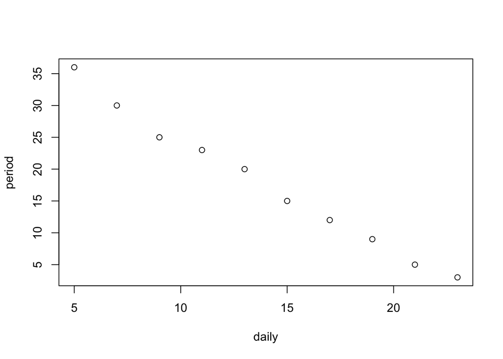

```
## [1] -0.9949424
```

```
##
##  Pearson's product-moment correlation
##
## data:  daily and period
## t = -28.016, df = 8, p-value = 2.845e-09
## alternative hypothesis: true correlation is not equal to 0
## 95 percent confidence interval:
##  -0.9988483 -0.9779365
## sample estimates:
##        cor
## -0.9949424
```

##### 2.

분산분석표를 작성하고 추정된 회귀직선이 유의한지 유의수준 5% 하에서 검정하시오.

2-1.분산분석표

```
##             Df Sum Sq Mean Sq F value   Pr(>F)
## daily        1 1054.8  1054.8   784.9 2.85e-09 ***
## Residuals    8   10.8     1.3
## ---
## Signif. codes:  0 '***' 0.001 '**' 0.01 '*' 0.05 '.' 0.1 ' ' 1
```

2-2.회귀 직선 추정

```
##
## Call:
## lm(formula = smoke$period ~ smoke$daily)
##
## Residuals:
##     Min      1Q  Median      3Q     Max
## -1.7394 -0.4061 -0.2242  0.3439  2.1091
##
## Coefficients:
##             Estimate Std. Error t value Pr(>|t|)
## (Intercept) 42.83030    0.96572   44.35 7.37e-11 ***
## smoke$daily -1.78788    0.06382  -28.02 2.85e-09 ***
## ---
## Signif. codes:  0 '***' 0.001 '**' 0.01 '*' 0.05 '.' 0.1 ' ' 1
##
## Residual standard error: 1.159 on 8 degrees of freedom
## Multiple R-squared:  0.9899, Adjusted R-squared:  0.9886
## F-statistic: 784.9 on 1 and 8 DF,  p-value: 2.845e-09
```

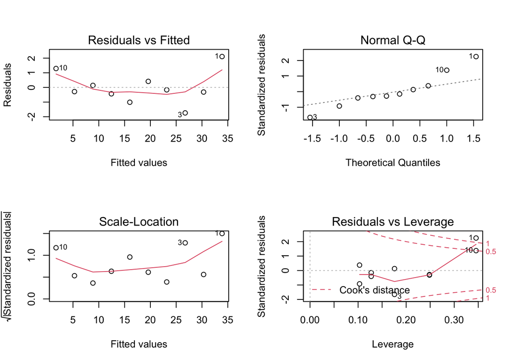

##### 3.

결정계수를 구하고 그 의미를 설명하시오.

결정 계수 ( R squared ) : 0.989

회귀분석을 통해 구한 결정계수는, 추정된 회귀식이 자료를 98.9% 설명한다 라는 의미를 보여준다.

##### 4.

회귀모형 추정식을 쓰고, 의미를 설명하시오.

추정식: y = 42.83 - 1.788x

(y=period(폐암 발생 후 사망 시점), x = daily(하루 흡연 수))

##### 5.

회귀모형에서 오차에 대한 가정을 쓰고, 자료가 회귀모형을 적용하기에 적절한지 설명하시오

##### 6.

하루 흡연 수가 10인 경우, 폐암 발생 후 예상되는 사망시점은?

```r
x = 10
y = 42.83 - 1.788 * x

print(y)
```

```
## [1] 24.95
```

```r
# y = 24.95 (1 month)

# 1year 12 month =  365 day , 1 month estimate 30.417 days

#if 1 month = 30.417days
#    0.95 month =  30.417 *0.95 days
#
print(0.95 * 30.417)
```

```
## [1] 28.89615
```

예상되는 사망시점

폐암 발생 후 24.95 월후

폐암 발생 후 약 2 년 28일